# Creating Choropleth maps with ggplot2

# Learning objectives

In this lesson, you will mainly learn how to use `ggplot()` and `geom_sf()` to create nice choropleth maps.

More specifically, you will learn how to:

1. Matching raw data to polygons
   - Get boundaries/polygons
   - Get disease related data
   - Join by admnistrative level
2. Applying Color scaling for continuous and discrete variables
   - Continuous
   - Discre
3. Applying Facet Wrap and Grid
   - Creating small multiples and using `facet_wrap()`
   - Creating small multiples and using `facet_grid()`

# 1 Introduction

A choropleth map is a thematic map in which geographic regions are shaded or patterned in proportion to the value of a variable being represented. This variable can be an epidemiological indicator such as disease prevalence or mortality rate. Choropleth maps are particularly useful for visualizing spatial patterns and variations across different regions.

The essential components of a choropleth map include:

**Geographic Regions**: These are the areas that will be represented on the map, such as countries, states, districts, or any other geographic divisions.

**Data Values**: These are the values associated with each geographic region that will be represented on the map, including population density, prevalence, incidence, mortality rate, etc.

**Color Scale**: This is the range of colors used to represent the different data values. Typically, a gradient of colors is used, with lighter colors representing lower values and darker colors representing higher values.

Choropleth maps have several notable advantages:

- **Visual Clarity**: They provide a clear visual representation of the spatial distribution of data, making it easier to identify patterns and trends.
- **Ease of Understanding**: They are intuitive and easy to understand, even for individuals without specialized knowledge in the field.
- **Versatility**: They can be used to represent a wide variety of data, making them suitable for various applications.

However, there are also important limitations to be aware of:

- **Data Sensitivity**: The appearance of the map can be significantly affected by the choice of data classification and color scale.
- **Geographic Size Bias**: Larger regions may appear more prominent on the map, leading to visual bias.

In the following section, you will learn how to create a choropleth map using the `ggplot2` package in R.

## 1.1 Packages

This code snippet demonstrates the loading of packages required for the analyses. In this guide, we emphasize `p_load()` from the `pacman` package, which installs the package if necessary and loads it for use. You can also load installed packages with `library()` from base R. See the page on R basics for more information on R packages.

```r
# Load packages
if(!require(pacman)) install.packages("pacman")
pacman::p_load(malariaAtlas,
               ggplot2,
               geodata,
               dplyr,
               here,
               sf,
               patchwork)
```

# 2 Data Preparation

Before creating a choropleth map, it is essential to prepare the data. The data should contain the geographic regions and the values you want to visualize.

In this section, you will go through the data preparation process, which includes the following steps:

1. **Import polygon data**: This is the geographical data that contains the boundaries of each region that you want to include in your map.
2. **Import attribute data**: This is the data that contains the values you want to visualize on the map, such as disease prevalence, population density, etc.
3. **Join the polygon and attribute data**: This step involves merging the polygon data with the attribute data based on a common identifier, such as the administrative level or region name. This will create a single dataset that contains both the geographic boundaries and the corresponding data values.

Now, let’s go through each step in detail.

## 2.1 Step 1: Import polygon data

Polygons are closed shapes with three or more sides. In spatial data, polygons are used to represent areas such as the boundary of a city, lake, or any land use type. They are essential in geographical information systems (GIS) for tasks like mapping, spatial analysis, and land cover classification.

Shapefiles are a common format for storing spatial data. They consist of at least three files with extensions .shp (shape), .shx (index), and .dbf (attribute data).

You can read shapefiles in R using the `sf` package.

```r
# Reading the shapefile
eth_adm1 <- sf::st_read(here::here("data/raw/ETH_Adm1_shapefile/ETH_Adm_1.shp"))
```

Below you can see that `geom_sf()` is used to trace the boundaries of the different regions of Ethiopia. Similarly, different layers can be added on top.

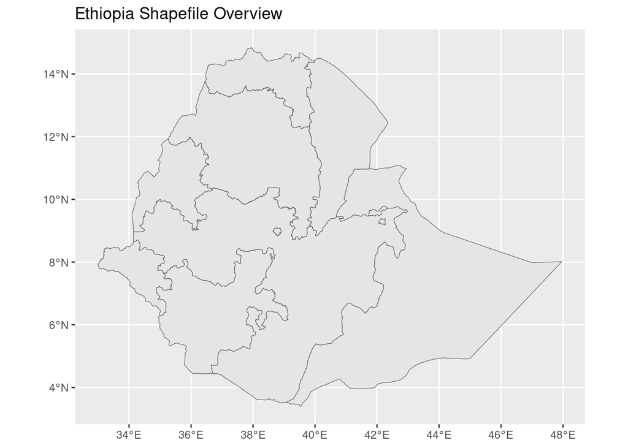

```r
ggplot()+
  geom_sf(data = eth_adm1)+
  labs(title = "Ethiopia Shapefile Overview")
```

Here, we first read the Ethiopia shapefile using `sf::st_read()` and then plot it using `ggplot2`. The `geom_sf()` function is used to render the spatial data, and `labs()` is used to add a title to the plot.

## 2.2 Step 2: Import Attribute Data

```r
# Reading the attribute data
tb_cases <- read_csv(here::here("data/tb_cases.csv"))
```

## 2.3 Step 3: Join Data by Administrative Levels

Before joining the two datasets, we need to define the join key (`by =`).

```r
# Add population data and calculate cases per 10K population
tb <- eth_adm1 %>%
     left_join(tb_cases,
               by = c("NAME_1")) %>%
     st_as_sf() # convert to shapefile
```

You can keep only the important variables that will be used in the construction of the plots.

Reminder: You can check the names of all your columns by using `names()`.

In this step, we first read the TB cases data using `read_csv()`. Then, we merge the shapefile data `eth_adm1` with the TB cases data `tb_cases` using `left_join()` from the `dplyr` package. The `by` argument is used to specify the common column(s) on which to merge the datasets. Finally, we convert the merged data to a shapefile using `st_as_sf()`.

## 2.4 Checking and Validating the Joined Data

It is essential to check and validate the joined data to ensure that the merge was successful and the data is accurate.

```r
# Validate the joined data
all.equal(unique(eth_adm1$NAME_1), unique(tb_cases$NAME_1))
```

```
## [1] TRUE
```

In this code chunk, we compare the unique region names in the `eth_adm1` and `tb_cases` datasets using `all.equal()` to ensure that all the regions in the shapefile are matched with the corresponding regions in the attribute data. If the merge was successful, `all.equal()` should return `TRUE`. Otherwise, it will return a detailed description of the differences between the two sets of region names.

In this part of the lesson, you learned about the importance of administrative levels in spatial data and how to join spatial and attribute data by administrative levels using the `dplyr` package in R and how to check and validate the joined data.

# 3 Creating a Beautiful Choropleth Map with `ggplot2`

## 3.1 Using the Fill Variable (i.e., Attribute Variable)

To display the number of cases, you need to fill the polygons drawn with `geom_sf()` using the `fill` variable. This is very straightforward as it follows the same logic as the syntax of `ggplot2` package.

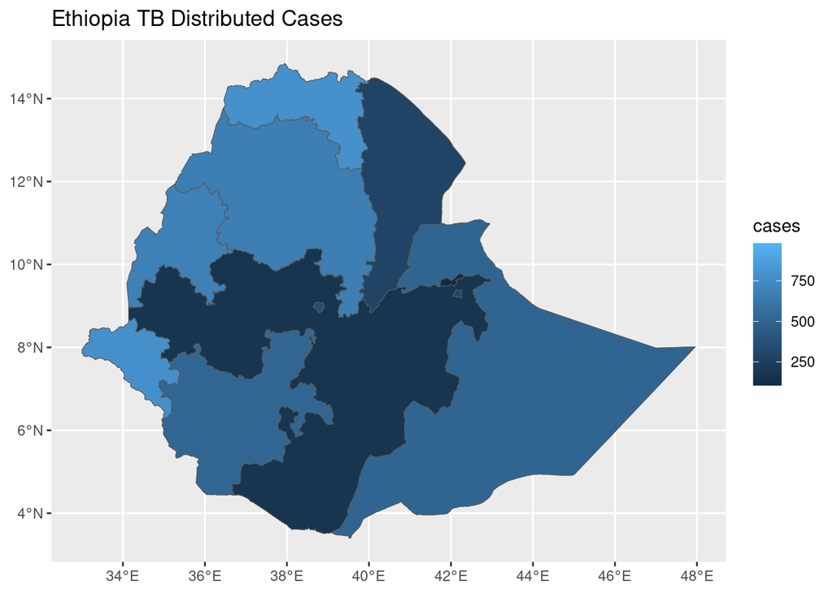

```r
ggplot(data=tb) +
  geom_sf(aes(fill=cases)) +   # set fill to vary by case count variable
  labs(title = "Ethiopia TB Distributed Cases")
```

## 3.2 Customizing the Map

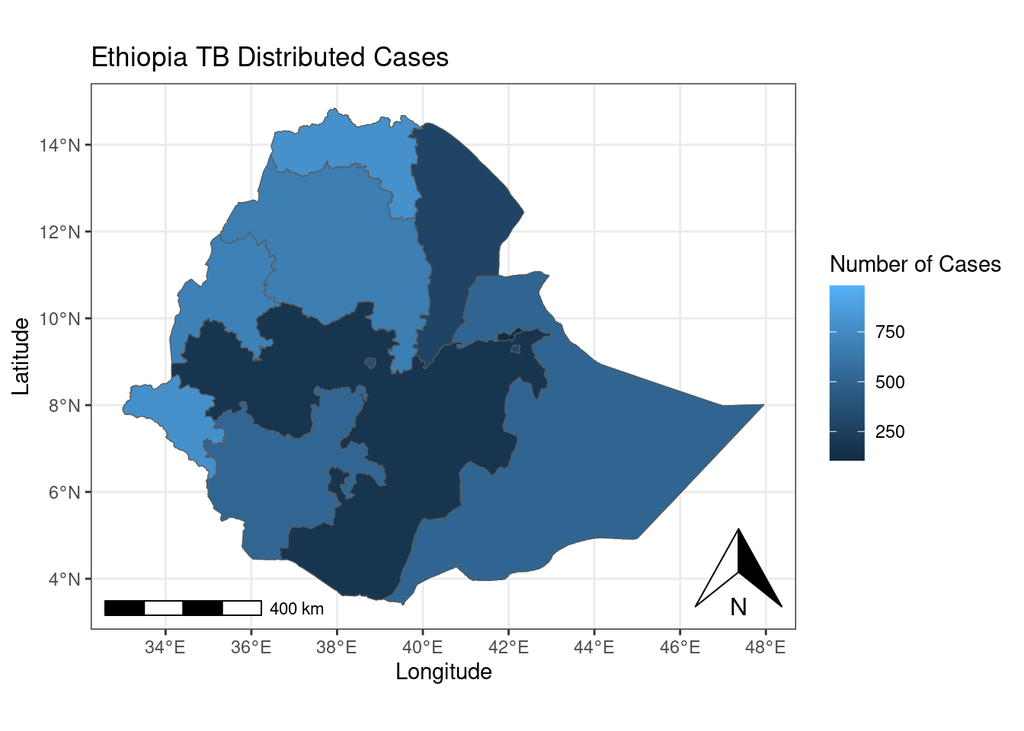

```r
ggplot(data=tb) +
  geom_sf(aes(fill=cases)) +   # set fill to vary by case count variable
  labs(title = "Ethiopia TB Distributed Cases",
       fill = "Number of Cases") +
  xlab("Longitude")+
  ylab("Latitude")+
  ggspatial::annotation_north_arrow(location = "br")+
  ggspatial::annotation_scale(location = "bl")+
  theme_bw()
```

In the first code chunk, we create a basic choropleth map using `ggplot2`. The `fill` aesthetic is set to vary by the `cases` variable, which colors the regions based on the number of TB cases.

In the second code chunk, we customize the map by adding titles to the axes and the legend, adding a north arrow and scale bar using `ggspatial::annotation_north_arrow()` and `ggspatial::annotation_scale()`, and changing the theme to `theme_bw()`.

# 4 Color Scaling

## 4.1 Color Scaling for Continuous Attributes

The `scale_fill_continuous()` function from the `ggplot2` package in R is used to apply continuous color scaling to a choropleth map.

You can customize the color palette used for continuous color scaling by specifying the `low` and `high` parameters in the `scale_fill_continuous()` function.

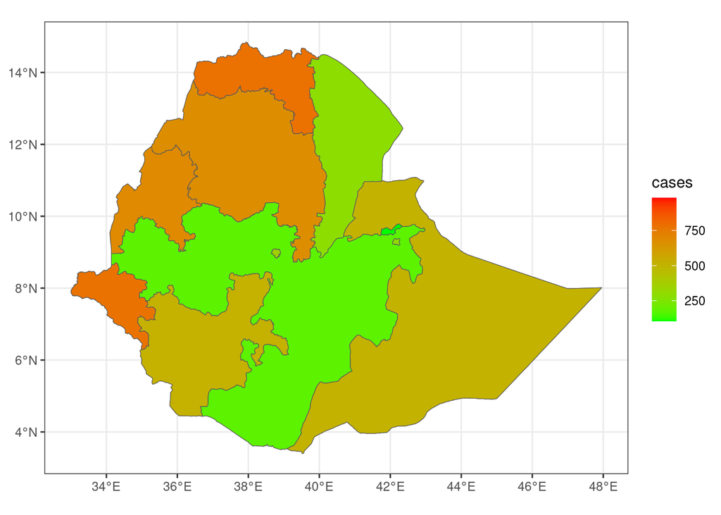

```r
# Create a ggplot object
ggplot(data = tb) +
  geom_sf(aes(fill = cases))+
  scale_fill_continuous(low = "green", high = "red")+ # apply continuous color scaling
  theme_bw()
```

In this section, you learned about continuous data and its importance in choropleth maps. You also learned how to apply continuous color scaling to a choropleth map using the `scale_fill_continuous()` function from the `ggplot2` package in R and how to customize the color palette.

## 4.2 Color Scaling for Discrete Attributes

Discrete data is a type of quantitative data that can only take specific, separate values. It is often the result of counting objects or events. Discrete data is important in choropleth maps as it allows us to represent the count or quantity of objects or events in different regions. Using distinct colors or patterns to represent discrete data helps in visualizing the data distribution and identifying patterns, trends, and outliers.

The `scale_fill_brewer()` function from the `ggplot2` package in R is used to apply discrete color scaling to a choropleth map.

Before applying the discrete color scaling, you will need to create a new discrete column, which could be a risk level based on the number of cases. For this, you can use `mutate()` combined with `case_when()`.

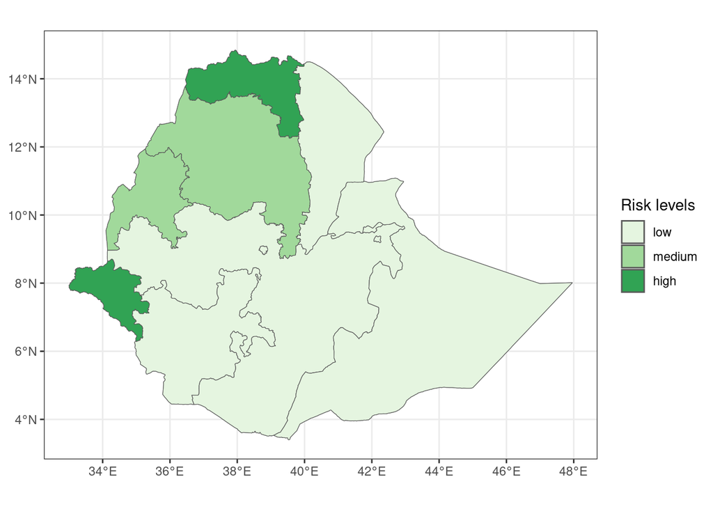

```r
tb %>%
  mutate(risk = case_when(cases < quantile(cases, 0.5) ~ 'low',
                          cases > quantile(cases, 0.75) ~ 'high',
                          TRUE ~ 'medium')) -> tb2

ggplot(data = tb2) + # Create a ggplot object
  geom_sf(aes(fill =  fct_reorder(risk, cases)))+ # reorder the risk labels according to the number of cases
  scale_fill_brewer(palette = "Set4", "Risk levels")+ # set palette and rename legend
  theme_bw()
```

You can also create a custom color palette for discrete variables.

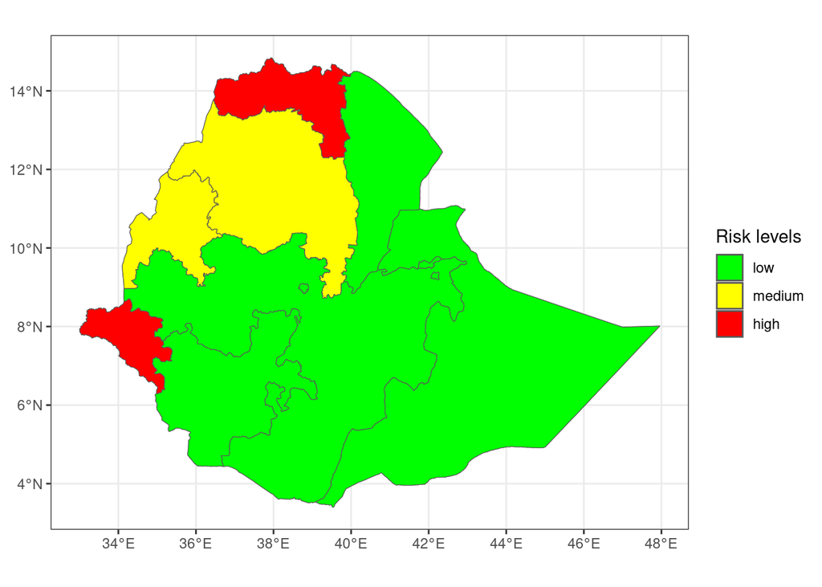

```r
custom_palette <- c("green", "yellow", "red") # create a custom color palette manually

# Apply custom color palette
ggplot(data = tb2) + # Create a ggplot object
   geom_sf(aes(fill =  fct_reorder(risk, cases)))+ # reorder the risk labels according to the number of cases
   scale_fill_manual(values = custom_palette, "Risk levels") +
   coord_sf(expand = TRUE)+
   theme_bw()
```

In this lesson, you learned about discrete data and its importance in choropleth maps. You also learned how to apply discrete color scaling to a choropleth map using the `scale_fill_brewer()` function from the `ggplot2` package in R and how to customize the color palette.

# 5 Facet Wrap vs. Grid

- `facet_wrap()`: This function wraps a 1D sequence of panels into 2D. This is useful when you have a single variable with many levels and want to arrange the plots in a more space-efficient manner.
- `facet_grid()`: This function creates a matrix of panels defined by row and column faceting variables. It is most useful when you have two discrete variables, and all combinations of the variables exist in the data.
- `facet_wrap()` is used for single variable faceting, while `facet_grid()` is used for two-variable faceting.
- `facet_wrap()` arranges the panels in a 2D grid, while `facet_grid()` arranges them in a matrix.

## 5.1 Creating Small Multiples using facet_wrap()

You can use the `facet_wrap()` function to create small multiples based on a given variable. In the following example, you can use the `year` variable.

Note: Remember that color scaling can be adjusted by `scale_fill_continuous()` if the variable is continuous or by `scale_fill_brewer()` if the variable is discrete.

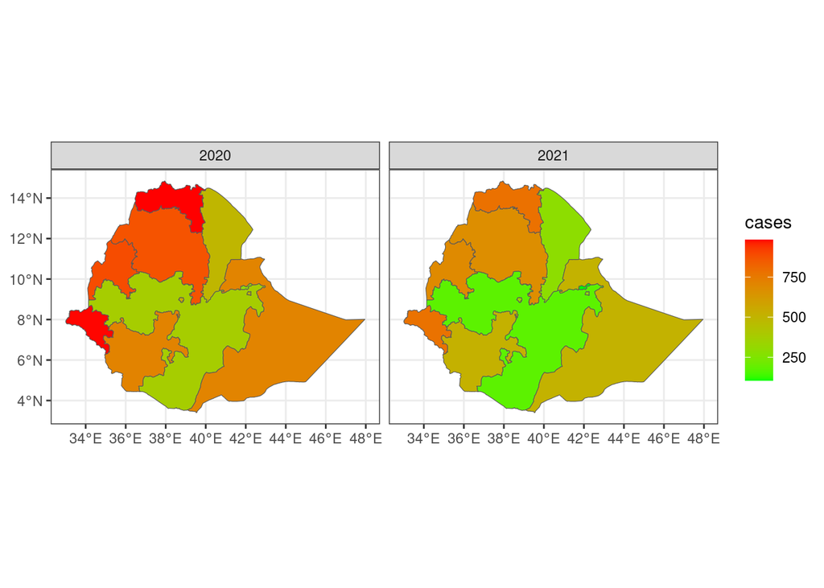

```r
# Create ggplot object using facet_wrap
ggplot(data = tb) +
  geom_sf(aes(fill = cases)) +
  facet_wrap(~ year)+
  scale_fill_continuous(low = "green", high = "red") + # apply continuous color scaling
  theme_bw()
```

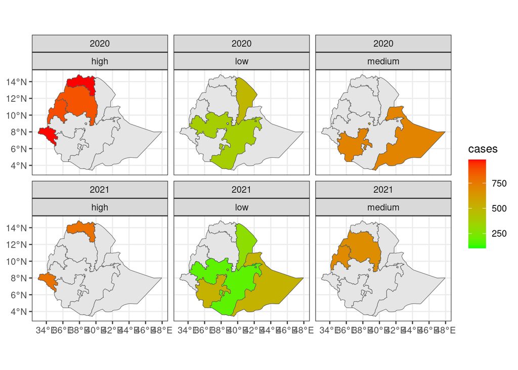

```r
ggplot() +
  geom_sf(data = eth_adm1) + # need the
  geom_sf(aes(fill = cases), data = tb2) +
  facet_wrap(year ~ risk)+
  coord_sf(expand = TRUE)+
  scale_fill_continuous(low = "green", high = "red")+
  theme_bw()
```

There remains only one concern, which is the overlapping of the x-axis!

Here, `geom_sf()` should work seamlessly with `ggplot2::scale_*_continuous()`, where you can use the `breaks =` argument.

In the last plot, you will notice that we used a continuous fill variable, but we also used a `facet_wrap` on two other discrete variables.

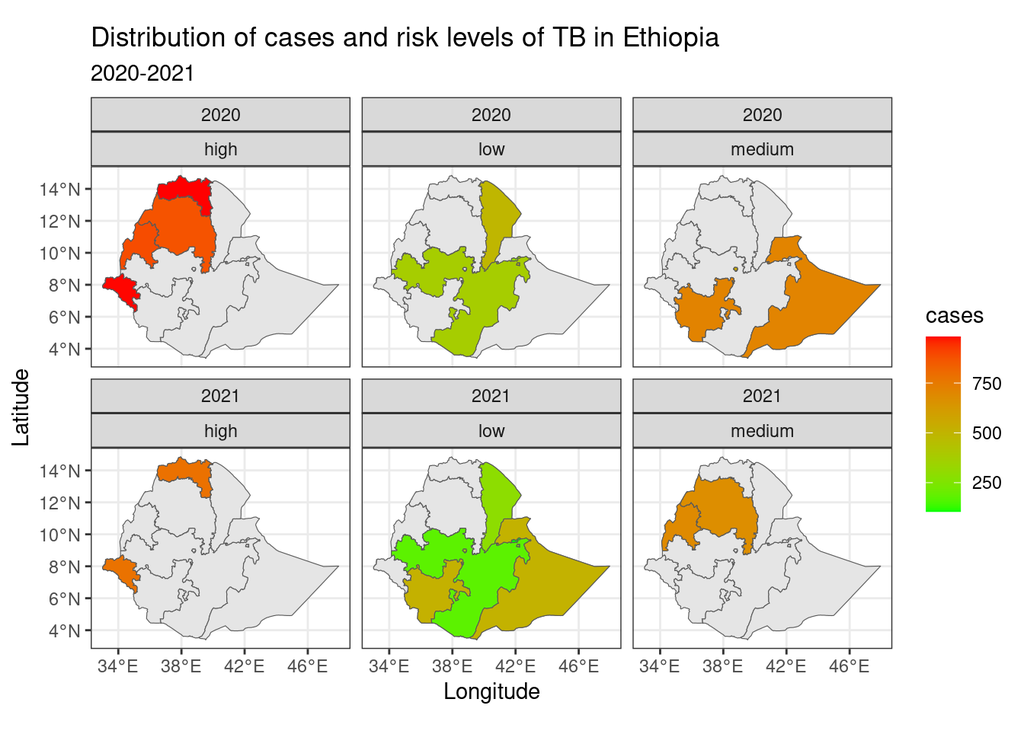

```r
ggplot() +
  geom_sf(data = eth_adm1) + # need the
  geom_sf(aes(fill = cases), data = tb2) +
  scale_x_continuous(breaks = seq(34, 48, by = 4)) +
  facet_wrap(year ~ risk)+
  coord_sf(expand = TRUE)+
  scale_fill_continuous(low = "green", high = "red")+
  labs(title = "Distribution of cases and risk levels of TB in Ethiopia",
       subtitle = "2020-2021")+
  xlab("Longitude")+
  ylab("Latitude")+
  theme_bw()
```

# 6 Conclusion

Congratulations, you have made it to the end of the lesson!

In this lesson, you have learned:

With this knowledge, you are now equipped to create your own choropleth maps using `ggplot2` in R.

# 7 Final Thoughts

Creating choropleth maps is an essential skill for anyone working with geographical data. With the tools and techniques you’ve learned in this lesson, you can now create your own choropleth maps using ggplot2 in R. Don’t hesitate to experiment with different datasets, color palettes, and faceting variables to create informative and visually appealing maps. Happy mapping!

# 8 Exercises

1. Create a choropleth map of your own country, showing the distribution of a variable of your choice (e.g., population density, literacy rate, etc.).
2. Customize the color palette of your map.
3. Create small multiples of your map, faceted by a variable of your choice (e.g., year, region, etc.).

# References

- ggplot2: Elegant Graphics for Data Analysis by Hadley Wickham
- R for Data Science by Hadley Wickham and Garrett Grolemund
- Geocomputation with R by Robin Lovelace, Jakub Nowosad, and Jannes Muenchow

# WRAP UP!

# Solution

# Contributors